# Analysis Pipeline for the Paper Functionally Enigmatic Genes: Are We Still Looking Under the Lamppost for the Lost Keys?

Constructing the gene network and identifying modules:

```r
net_COAD = blockwiseModules(COADdata1, power = 6,
                            TOMType = "unsigned", minModuleSize = 30,
                            reassignThreshold = 0, mergeCutHeight = 0.25,
                            numericLabels = TRUE, pamRespectsDendro = FALSE,
                            saveTOMs = TRUE,
                            saveTOMFileBase = "COADTOM",
                            verbose = 3)
```

```
##  Calculating module eigengenes block-wise from all genes
##    Flagging genes and samples with too many missing values...
##     ..step 1
##  ....pre-clustering genes to determine blocks..
##    Projective K-means:
##    ..k-means clustering..
##    ..merging smaller clusters...
## Block sizes:
## gBlocks
##    1    2    3
## 4991 4947   62
##  ..Working on block 1 .
##     TOM calculation: adjacency..
##     ..will not use multithreading.
##      Fraction of slow calculations: 0.000000
##     ..connectivity..
##     ..matrix multiplication (system BLAS)..
##     ..normalization..
##     ..done.
##    ..saving TOM for block 1 into file COADTOM-block.1.RData
##  ....clustering..
##  ....detecting modules..
##  ....calculating module eigengenes..
##  ....checking kME in modules..
##      ..removing 244 genes from module 1 because their KME is too low.
##      ..removing 13 genes from module 2 because their KME is too low.
##      ..removing 2 genes from module 4 because their KME is too low.
##      ..removing 4 genes from module 5 because their KME is too low.
##      ..removing 6 genes from module 7 because their KME is too low.
##      ..removing 1 genes from module 8 because their KME is too low.
##      ..removing 1 genes from module 9 because their KME is too low.
##      ..removing 1 genes from module 10 because their KME is too low.
##      ..removing 3 genes from module 12 because their KME is too low.
##  ..Working on block 2 .
##     TOM calculation: adjacency..
##     ..will not use multithreading.
##      Fraction of slow calculations: 0.000000
##     ..connectivity..
##     ..matrix multiplication (system BLAS)..
##     ..normalization..
```

[output cut: 15 more lines]

```
##     TOM calculation: adjacency..
##     ..will not use multithreading.
##      Fraction of slow calculations: 0.000000
##     ..connectivity..
##     ..matrix multiplication (system BLAS)..
##     ..normalization..
##     ..done.
##    ..saving TOM for block 3 into file COADTOM-block.3.RData
##  ....clustering..
##  ....detecting modules..
##  ....calculating module eigengenes..
##  ....checking kME in modules..
##  ..merging modules that are too close..
##      mergeCloseModules: Merging modules whose distance is less than 0.25
##        Calculating new MEs...
```

Check how many modules were identified and what the module sizes are:

```r
table(net_COAD$colors)
```

```
##
##    0    1    2    3    4    5    6    7    8    9   10   11   12   13   14
## 1959 1865 1470  747  702  602  544  431  329  295  208  171  144  125   97
##   15   16   17   18   19   20
##   62   60   57   53   45   34
```

Now we can visualize the modules:

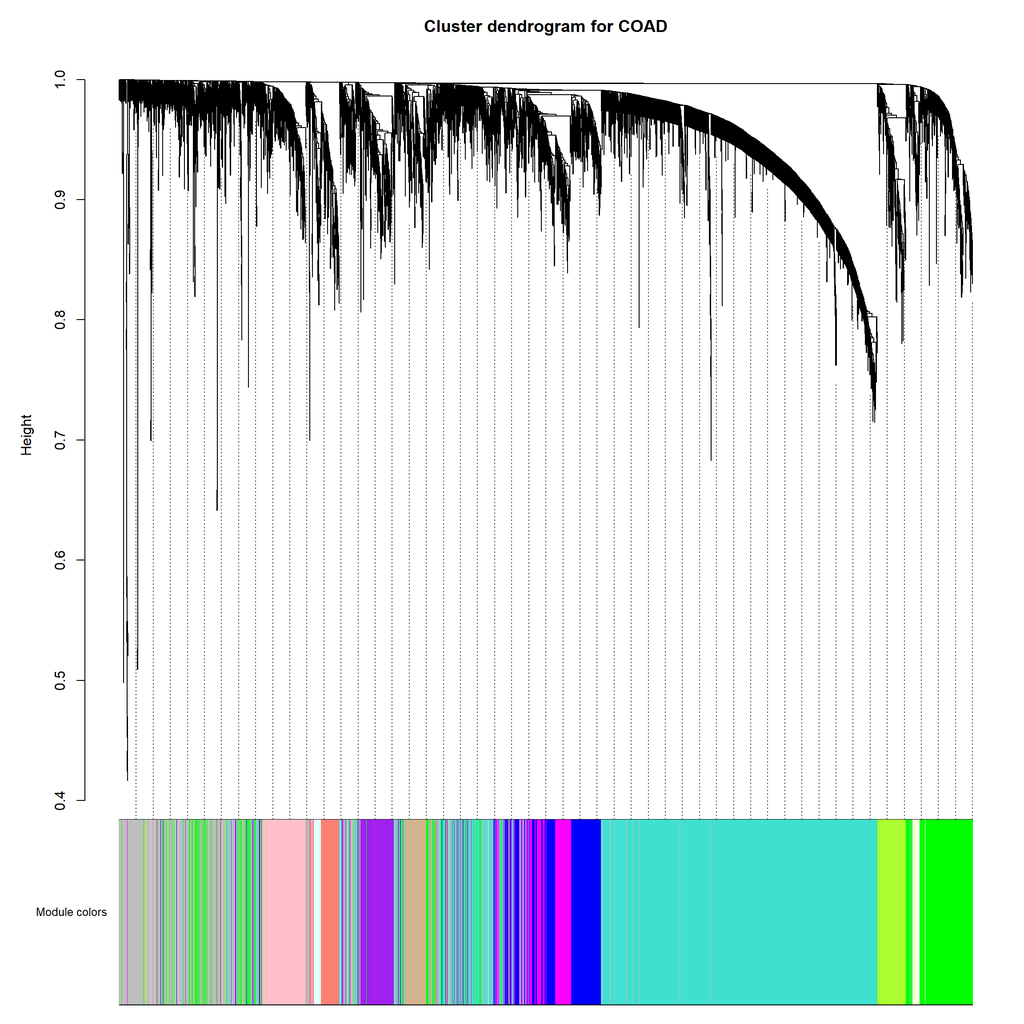

```r
#Convert labels to colors for plotting
mergedColors_COAD = labels2colors(net_COAD$colors)

#Plot the dendrogram and the module colors underneath
plotDendroAndColors(net_COAD$dendrograms[[1]], mergedColors_COAD[net_COAD$blockGenes[[1]]],
                    "Module colors",
                    dendroLabels = FALSE, hang = 0.03,
                    addGuide = TRUE, guideHang = 0.05, main = "Cluster dendrogram for COAD")
```

We now save the module assignment and module eigengene information necessary for subsequent analysis:

```r
moduleLabels_COAD = net_COAD$colors
moduleColors_COAD = labels2colors(net_COAD$colors)
MEs_COAD = net_COAD$MEs;
geneTree_COAD = net_COAD$dendrograms[[1]];
save(MEs_COAD, moduleLabels_COAD, moduleColors_COAD, geneTree_COAD,
     file = "Data Outputs/COADnetwork_modulecolor_and_label.RData")
```

Create a data frame holding the following information for all genes: gene names, module color,and module membership and p-values in all modules:

```r
#Define numbers of genes and samples
nGenes = ncol(COADdata1)
nSamples = nrow(COADdata1)

#Recalculate MEs with color labels
MEs0_COAD = moduleEigengenes(COADdata1, moduleColors_COAD)$eigengenes
MEs_COAD = orderMEs(MEs0_COAD)

#Get the names (colors) of the modules
modNames_COAD = substring(names(MEs_COAD), 3)
geneModuleMembership_COAD = as.data.frame(cor(COADdata1, MEs_COAD, use = "p"));
MMPvalue_COAD = as.data.frame(corPvalueStudent(as.matrix(geneModuleMembership_COAD), nSamples))
names(geneModuleMembership_COAD) = paste("MM", modNames_COAD, sep="")
names(MMPvalue_COAD) = paste("p.MM", modNames_COAD, sep="")
```

We now create a data frame holding the following information for all genes: gene names, module color, module membership, and p-values in all modules.

Create the starting data frame:

```r
geneInfoCOAD = data.frame(Genename = colnames(COADdata1),
                          moduleColor = moduleColors_COAD,
                          geneModuleMembership_COAD,
                          MMPvalue_COAD)
```

Order the genes in the geneInfo variable by module color:

```r
geneOrder_COAD = order(geneInfoCOAD$moduleColor)
geneInfoCOAD_1 = geneInfoCOAD[geneOrder_COAD, ]
```

Save the data:

```r
save(geneInfoCOAD_1, file = "Data Outputs/COAD_geneMM.Rdata")
```

Now we calculate scaled connectivity of genes in the COAD network.

Create a TOM matrix:

```r
tom_COAD = TOMsimilarityFromExpr(COADdata1)
```

```
## TOM calculation: adjacency..
## ..will not use multithreading.
##  Fraction of slow calculations: 0.000000
## ..connectivity..
## ..matrix multiplication (system BLAS)..
## ..normalization..
## ..done.
```

```r
fun = fundamentalNetworkConcepts(tom_COAD, GS = NULL) #Take > 30 minutes to compute
```

We want the scaled connectivity k = connectivity/max(connectivity), which is an indication of hub gene significance:

```r
connectivity_COAD = as.data.frame(fun$ScaledConnectivity)
row.names(connectivity_COAD) = colnames(COADdata1)
```

To visualize correlation between scaled connectivity of genes and number of publications, we first need to merge the two variables into one dataframe:

```r
connectivity_COAD = tibble::rownames_to_column(connectivity_COAD, "gene") #To make the rowname column into a new column
connectivity_COAD = separate(connectivity_COAD, 1, into = c("genename", "entrez"), sep = "([|])", remove = FALSE) #Separate the "gene" column
row.names(connectivity_COAD) = connectivity_COAD$gene #Reformat the connectivity_COAD dataframe
connectivity_COAD = connectivity_COAD[,-1]
```

Now we can merge genesig_COAD and PubMed:

```r
connectivity_PubMed_COAD = merge(PubMed, connectivity_COAD, by = "entrez")
connectivity_PubMed_COAD = connectivity_PubMed_COAD[, -4]
colnames(connectivity_PubMed_COAD) = c("entrez", "genename", "PubMed", "scaledconnectivity")
```

Save the data:

```r
save(connectivity_PubMed_COAD, file = "Data Outputs/Scaled connectivity and PubMed ID for COAD.Rdata")
```

We also create a data frame containing scaled connectivity and aggressiveness score:

```r
aggressiveness_COAD = as.data.frame(COAD.aggressiveness[, c(3,7)])
aggressiveness_connectivity_PubMed_COAD = merge(connectivity_PubMed_COAD, aggressiveness_COAD, by = "genename") #Merge with connectivity_PubMed_COAD
```

Save the data:

```r
save(aggressiveness_connectivity_PubMed_COAD, file = "Data Outputs/Scaled connectivity, PubMed IDs, and aggressivenss score for COAD.Rdata")
```

# 4. WGCNA Analysis for glioma (GBMLGG) data set

## 4a. Data pre-processing

Remove uninformative data:

```r
GBMLGG = GBMLGG_DATA
row.names(GBMLGG) = GBMLGG_DATA[,1]; colnames(GBMLGG) = GBMLGG_DATA[1,]
GBMLGG = GBMLGG[-c(1,2),-1]
```

Convert data frame to numeric matrix:

```r
GBMLGG1 = as.matrix(sapply(GBMLGG, as.numeric))
colnames(GBMLGG1) = colnames(GBMLGG)
row.names(GBMLGG1) = row.names(GBMLGG)
class(GBMLGG1)
```

```
## [1] "matrix"
```

```r
is.numeric(GBMLGG1)
```

```
## [1] TRUE
```

Transpose matrix and filter for 10,000 most variant genes:

```r
GBMLGGdata = t(GBMLGG1[order(apply(GBMLGG1,1,mad), decreasing = T)[1:10000],])
```

Check if GBMLGGdata have many missing values:

```r
gsg = goodSamplesGenes(GBMLGGdata, verbose = 3)
```

```
##  Flagging genes and samples with too many missing values...
##   ..step 1
```

```r
gsg$allOK
```

```
## [1] TRUE
```

The command returns “TRUE”, so all genes have passed the cuts.

Re-cluster the samples (in contrast to clustering genes that will come later) to see if there are any obvious outliers:

```r
sampleTree = hclust(dist(GBMLGGdata), method = "average")
# Plot the sample tree:
sizeGrWindow(12,9)
par(cex = 0.6);
par(mar = c(0,4,2,0))
plot(sampleTree, main = "Sample clustering to detect outliers", sub="", xlab="", cex.lab = 1.5,
     cex.axis = 1.5, cex.main = 2)
```

It appears there is 1 outlier. We next remove the outlier.

Plot a line to show the cut:

```r
sizeGrWindow(12,9)
par(cex = 0.6);
par(mar = c(0,4,2,0))
plot(sampleTree, main = "Sample clustering to detect outliers", sub="", xlab="", cex.lab = 1.5,
     cex.axis = 1.5, cex.main = 2)
abline(h = 2500000, col = "red")
```

Determine cluster under the line:

```r
clust = cutreeStatic(sampleTree, cutHeight = 2500000, minSize = 10)
table(clust)
```

```
## clust
##   0   1
##   1 700
```

Clust 1 contains the samples we want to keep:

```r
keepSamples = (clust==1)
GBMLGGdata1 = GBMLGGdata[keepSamples, ]
```

Now the GBMLGGdata1 matrix is ready for WGCNA analysis

## 4b. Network analysis using WGCNA

Choose a set of soft-thresholding powers:

```r
powers = c(c(1:10), seq(from = 12, to=20, by=2))
```

Call the network topology analysis function:

```r
sft = pickSoftThreshold(GBMLGGdata1, powerVector = powers, verbose = 5)
```

Plot the results:

```r
sizeGrWindow(9, 5)
par(mfrow = c(1,2));
cex1 = 0.9;
# Scale-free topology fit index as a function of the soft-thresholding power
plot(sft$fitIndices[,1], -sign(sft$fitIndices[,3])*sft$fitIndices[,2],
     xlab="Soft Threshold (power)",ylab="Scale Free Topology Model Fit,signed R^2",type="n",
     main = paste("Scale independence"));
text(sft$fitIndices[,1], -sign(sft$fitIndices[,3])*sft$fitIndices[,2],
     labels=powers,cex=cex1,col="red");
# this line corresponds to using an R^2 cut-off of h
abline(h=0.90,col="red")
# Mean connectivity as a function of the soft-thresholding power
plot(sft$fitIndices[,1], sft$fitIndices[,5],
     xlab="Soft Threshold (power)",ylab="Mean Connectivity", type="n",
     main = paste("Mean connectivity"))
text(sft$fitIndices[,1], sft$fitIndices[,5], labels=powers, cex=cex1,col="red")
```

Based on the scale-free topology graph, the soft-thresholding power of 6 was chosen.

Constructing the gene network and identifying modules:

```r
net_GBMLGG = blockwiseModules(GBMLGGdata1, power = 6,
                              TOMType = "unsigned", minModuleSize = 30,
                              reassignThreshold = 0, mergeCutHeight = 0.25,
                              numericLabels = TRUE, pamRespectsDendro = FALSE,
                              saveTOMs = TRUE,
                              saveTOMFileBase = "GBMLGGTOM",
                              verbose = 3)
```

To see how many modules were identified and what the module sizes are, one can use table(net$colors):

```r
table(net_GBMLGG$colors)
```

```
##
##   0   1   2   3   4   5   6   7   8   9  10  11  12  13  14  15  16  17
## 965 990 942 849 781 725 496 461 379 348 341 311 285 261 250 226 150 141
##  18  19  20  21  22  23  24  25  26  27  28  29  30  31  32
## 112 112 104  90  75  74  70  66  66  65  63  62  60  46  34
```

Now we can visualize the modules.

Convert labels to colors for plotting:

```r
mergedColors_GBMLGG = labels2colors(net_GBMLGG$colors)
```

Plot the dendrogram and the module colors underneath:

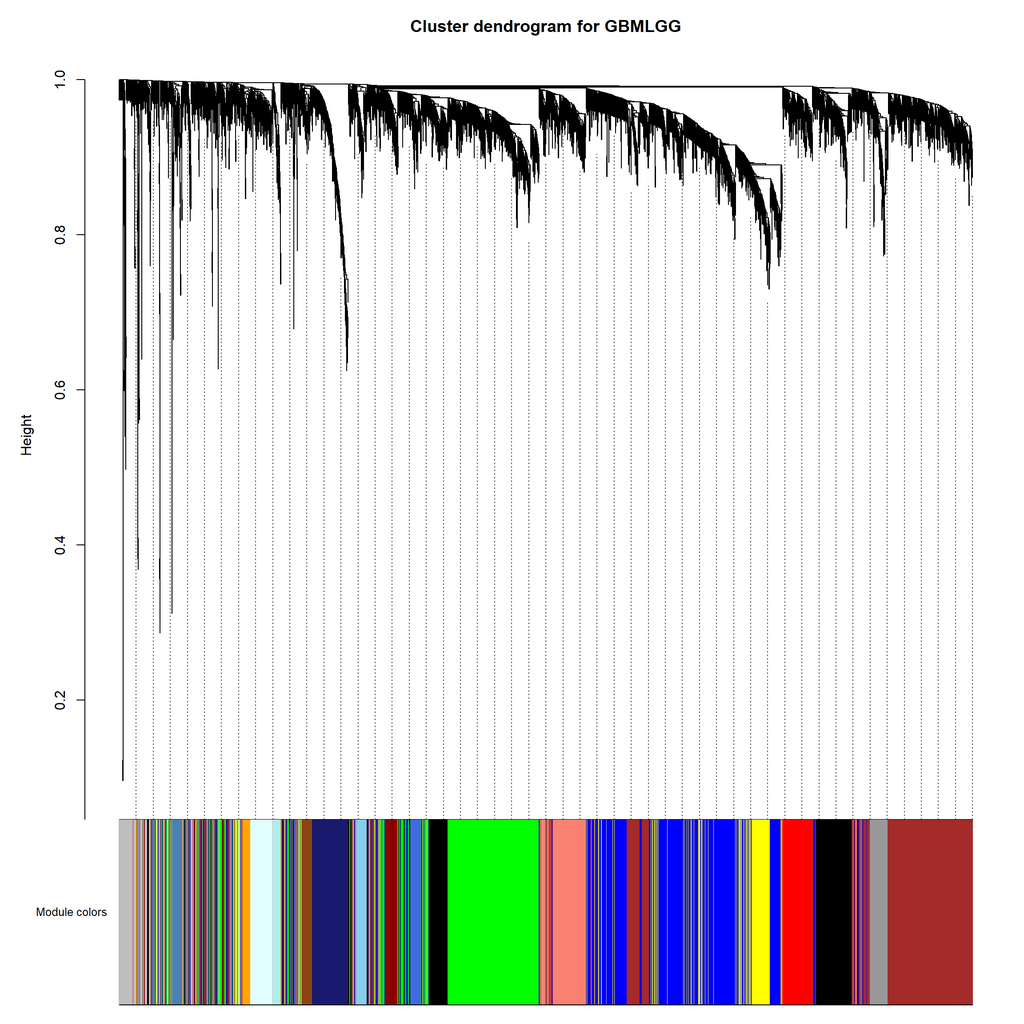

```r
plotDendroAndColors(net_GBMLGG$dendrograms[[1]], mergedColors_GBMLGG[net_GBMLGG$blockGenes[[1]]],
                    "Module colors",
                    dendroLabels = FALSE, hang = 0.03,
                    addGuide = TRUE, guideHang = 0.05, main = "Cluster dendrogram for GBMLGG")
```

We now save the module assignment and module eigengene information necessary for subsequent analysis:

```r
moduleLabels_GBMLGG = net_GBMLGG$colors
moduleColors_GBMLGG = labels2colors(net_GBMLGG$colors)
MEs_GBMLGG = net_GBMLGG$MEs;
geneTree_GBMLGG = net_GBMLGG$dendrograms[[1]];
save(MEs_GBMLGG, moduleLabels_GBMLGG, moduleColors_GBMLGG, geneTree_GBMLGG,
     file = "Data Outputs/GBMLGG_network_modulecolor_and_label.RData")
```

Define numbers of genes and samples:

```r
nGenes = ncol(GBMLGGdata1)
nSamples = nrow(GBMLGGdata1)
```

Recalculate MEs with color labels:

```r
MEs0_GBMLGG = moduleEigengenes(GBMLGGdata1, moduleColors_GBMLGG)$eigengenes
MEs_GBMLGG = orderMEs(MEs0_GBMLGG)
```

Calculate module membership to identify important genes:

```r
modNames_GBMLGG = substring(names(MEs_GBMLGG), 3) #Names (colors) of the modules
geneModuleMembership_GBMLGG = as.data.frame(cor(GBMLGGdata1, MEs_GBMLGG, use = "p"))
MMPvalue_GBMLGG = as.data.frame(corPvalueStudent(as.matrix(geneModuleMembership_GBMLGG), nSamples))
names(geneModuleMembership_GBMLGG) = paste("MM", modNames_GBMLGG, sep="")
names(MMPvalue_GBMLGG) = paste("p.MM", modNames_GBMLGG, sep="")
```

We now create a data frame holding the following information for all genes: gene names, module color, and module membership and p-values in all modules:

```r
geneInfoGBMLGG = data.frame(Genename = colnames(GBMLGGdata1), #Create the starting data frame
                            moduleColor = moduleColors_GBMLGG,
                            geneModuleMembership_GBMLGG,
                            MMPvalue_GBMLGG)

geneOrder_GBMLGG = order(geneInfoGBMLGG$moduleColor) #Order the genes in the geneInfo variable by module color
geneInfoGBMLGG_1 = geneInfoGBMLGG[geneOrder_GBMLGG, ]

save(geneInfoGBMLGG_1, file = "Data Outputs/GBMLGG_geneMM.Rdata") #Save the data frame
```

Now we calculate scaled connectivity of genes in the GBMLGG network.

Create a TOM matrix:

```r
tom_GBMLGG = TOMsimilarityFromExpr(GBMLGGdata1)
fun = fundamentalNetworkConcepts(tom_GBMLGG, GS = NULL) #Take > 30 minutes to compute
```

We want the scaled connectivity k = connectivity/max(connectivity), which is an indication of hub gene significance:

```r
connectivity_GBMLGG = as.data.frame(fun$ScaledConnectivity)
row.names(connectivity_GBMLGG) = colnames(GBMLGGdata1)
```

To visualize correlation between scaled connectivity of genes and number of publications, we merge the two variables into one dataframe:

```r
connectivity_GBMLGG = tibble::rownames_to_column(connectivity_GBMLGG, "gene") #To make the rowname column into a new column
connectivity_GBMLGG = separate(connectivity_GBMLGG, 1, into = c("genename", "entrez"), sep = "([|])", remove = FALSE) #Separate the "gene" column
row.names(connectivity_GBMLGG) = connectivity_GBMLGG$gene #Reformat the connectivity_GBMLGG dataframe
connectivity_GBMLGG = connectivity_GBMLGG[,-1] #Now we can merge genesig_COAD and PubMed
connectivity_PubMed_GBMLGG = merge(PubMed, connectivity_GBMLGG, by = "entrez")
connectivity_PubMed_GBMLGG = connectivity_PubMed_GBMLGG[, -4]
colnames(connectivity_PubMed_GBMLGG) = c("entrez", "genename", "PubMed", "scaledconnectivity")

save(connectivity_PubMed_GBMLGG, file = "Data Outputs/Scaled connectivity and PubMed ID for GBMLGG.Rdata")
```

We also create another data frame to correlate scaled connectivity with C index score, a metric for glioma severity:

```r
colnames(GBMLGG.Cindex) = c("genename", "entrez", "Q", "C_index")
Cindex_connectivity_PubMed_GBMLGG = merge(connectivity_PubMed_GBMLGG, GBMLGG.Cindex, by = "entrez") ##Add Cindex score to connectivity_PubMed_GBMLGG dataframe
Cindex_connectivity_PubMed_GBMLGG = Cindex_connectivity_PubMed_GBMLGG[, -c(2)]
dim(Cindex_connectivity_PubMed_GBMLGG)
```

```
## [1] 3009    6
```

```r
class(Cindex_connectivity_PubMed_GBMLGG)
```

```
## [1] "data.frame"
```

```r
colnames(Cindex_connectivity_PubMed_GBMLGG)[colnames(Cindex_connectivity_PubMed_GBMLGG) == "genename.y"] = "gemename"

save(Cindex_connectivity_PubMed_GBMLGG, file = "Data Outputs/Scaled connectivity, PubMed number, and Cindex score for GBMLGG.RData")
```

# 5. Examine the distribution of underannotated genes in modules

## 5a. Examine the distribution of underannotated genes in PRAD

For each module, we will determine how many underannotated genes there are, and calculate the percentage of underannotated genes.

Get the module names:

```r
Modulemembership_PRAD = geneInfoPRAD_1[,c(1,2)]
colnames(Modulemembership_PRAD) = c("genename", "modulecolor")
```

Separate the “genename” column and merge module color with PudMed publication numbers for each gene in each module:

```r
Modulemembership_PRAD = separate(Modulemembership_PRAD, 1, into = c("genename", "entrez"), sep = "([|])", remove = TRUE)
module_PubMed_PRAD = merge(Modulemembership_PRAD, PubMed, by = "entrez")
module_PubMed_PRAD = module_PubMed_PRAD[,-4]
module_PubMed_PRAD = as.data.frame(module_PubMed_PRAD)
```

Extract only underannoatation (PubMed <51) genes into a new data set:

```r
underannotated_PRAD = module_PubMed_PRAD[which(module_PubMed_PRAD$PubMed < 51),]
```

Count the number of all genes and underannotated genes in each module:

```r
allannotation_bymodule = aggregate(module_PubMed_PRAD$PubMed ~ module_PubMed_PRAD$modulecolor, data = module_PubMed_PRAD,length)
colnames(allannotation_bymodule) = c("modulecolor", "PubMed")

underannotation_bymodule = aggregate(underannotated_PRAD$PubMed ~ underannotated_PRAD$modulecolor, data = underannotated_PRAD,length)
colnames(underannotation_bymodule) = c("modulecolor", "PubMed")

annotation_bymodule = merge(allannotation_bymodule, underannotation_bymodule, by = "modulecolor")

colnames(annotation_bymodule) = c("Module.color", "Total.genes", "Functionally.enigmatic.genes")
```

Calculate the percentage of underannotated genes among all genes in each module:

```r
annotation_bymodule = mutate(annotation_bymodule, Percent.functionally.enigmatic.genes = Functionally.enigmatic.genes*100/Total.genes)
annotation_bymodule = arrange(annotation_bymodule, desc(Percent.functionally.enigmatic.genes))
annotation_bymodule_PRAD = as.data.frame(annotation_bymodule)
save(annotation_bymodule, file = "Data Outputs/Annotation by module PRAD.Rdata")
```

## 5b. Examine the distribution of underannotated genes in COAD

The process is similar to 5a.

```r
#Get the module names
Modulemembership_COAD = geneInfoCOAD_1[,c(1,2)]
colnames(Modulemembership_COAD) = c("genename", "modulecolor")

#Separate the "genename" column
Modulemembership_COAD = separate(Modulemembership_COAD, 1, into = c("genename", "entrez"), sep = "([|])", remove = TRUE)

#Merge the module color with PubMed ID
module_PubMed_COAD = merge(Modulemembership_COAD, PubMed, by = "entrez")
module_PubMed_COAD = module_PubMed_COAD[,-4]
module_PubMed_COAD = as.data.frame(module_PubMed_COAD)

#Extract only underannoatation (PubMed <51) genes into a new data set
underannotated_COAD = module_PubMed_COAD[which(module_PubMed_COAD$PubMed < 51),]

#Count the number of all genes and underannotated genes in each module
allannotation_bymodule = aggregate(module_PubMed_COAD$PubMed ~ module_PubMed_COAD$modulecolor, data = module_PubMed_COAD, length)
colnames(allannotation_bymodule) = c("modulecolor", "PubMed")
underannotation_bymodule = aggregate(underannotated_COAD$PubMed ~ underannotated_COAD$modulecolor, data = underannotated_COAD, length)
colnames(underannotation_bymodule) = c("modulecolor", "PubMed")
annotation_bymodule = merge(allannotation_bymodule, underannotation_bymodule, by = "modulecolor")
colnames(annotation_bymodule) = c("Module.color", "Total.genes", "Functionally.enigmatic.genes")

#Calculate the percentage of underannotated genes in each module
annotation_bymodule = mutate(annotation_bymodule, Percent.functionally.enigmatic.genes = Functionally.enigmatic.genes*100/Total.genes)
annotation_bymodule = arrange(annotation_bymodule, desc(Percent.functionally.enigmatic.genes))
annotation_bymodule_COAD = as.data.frame(annotation_bymodule)

save(annotation_bymodule_COAD, file = "Data Outputs/Annotation by module COAD.Rdata")
```

## 5c. Examine the distribution of underannotated genes in GBMLGG

```r
#Get the module names
Modulemembership_GBMLGG = geneInfoGBMLGG_1[,c(1,2)]
colnames(Modulemembership_GBMLGG) = c("genename", "modulecolor")

#Separate the "genename" column
Modulemembership_GBMLGG = separate(Modulemembership_GBMLGG, 1, into = c("genename", "entrez"), sep = "([|])", remove = TRUE)

#Merge the module color with PubMed ID
module_PubMed_GBMLGG = merge(Modulemembership_GBMLGG, PubMed, by = "entrez")
module_PubMed_GBMLGG = module_PubMed_GBMLGG[,-4]
module_PubMed_GBMLGG = as.data.frame(module_PubMed_GBMLGG)

#Extract only underannoatation (PubMed <51) genes into a new data set
underannotated_GBMLGG = module_PubMed_GBMLGG[which(module_PubMed_GBMLGG$PubMed < 51),]

#Count the number of all genes and underannotated genes in each module
allannotation_bymodule = aggregate(module_PubMed_GBMLGG$PubMed ~ module_PubMed_GBMLGG$modulecolor, data = module_PubMed_GBMLGG, length)
colnames(allannotation_bymodule) = c("modulecolor", "PubMed")
underannotation_bymodule = aggregate(underannotated_GBMLGG$PubMed ~ underannotated_GBMLGG$modulecolor, data = underannotated_GBMLGG, length)
colnames(underannotation_bymodule) = c("modulecolor", "PubMed")
annotation_bymodule = merge(allannotation_bymodule, underannotation_bymodule, by = "modulecolor")
colnames(annotation_bymodule) = c("Module.color", "Total.genes", "Functionally.enigmatic.genes")

#Calculate the percentage of underannotated genes in each module
annotation_bymodule = mutate(annotation_bymodule, Percent.functionally.enigmatic.genes = Functionally.enigmatic.genes*100/Total.genes)
annotation_bymodule = arrange(annotation_bymodule, desc(Percent.functionally.enigmatic.genes))
annotation_bymodule_GBMLGG = as.data.frame(annotation_bymodule)

save(annotation_bymodule_GBMLGG, file = "Data Outputs/Annotation by module GBMLGG.Rdata")
```

# 7. Create figure 2

We first calculate Kendall correlation between scaled connectivity and PubMed publications for each data sets.

Kendall correlation between scaled connectivity and PubMed publications for PRAD:

```r
corAndPvalue(connectivity_PubMed_PRAD$PubMed, connectivity_PubMed_PRAD$scaledconnectivity, method = "kendall")
```

```
## $cor
##             [,1]
## [1,] -0.02443942
##
## $p
##            [,1]
## [1,] 0.01452535
##
## $Z
##           [,1]
## [1,] -2.444185
##
## $t
##          [,1]
## [1,] 2.444428
##
## $nObs
##       [,1]
## [1,] 10000
```

Kendall correlation between scaled connectivity and PubMed publications for COAD:

```r
corAndPvalue(connectivity_PubMed_COAD$PubMed, connectivity_PubMed_COAD$scaledconnectivity, method = "kendall")
```

[output not shown]

Kendall correlation between scaled connectivity and PubMed publications for GBMLGG:

```r
corAndPvalue(connectivity_PubMed_GBMLGG$PubMed, connectivity_PubMed_GBMLGG$scaledconnectivity, method = "kendall")
```

```
## $cor
##              [,1]
## [1,] -0.005911161
##
## $p
##           [,1]
## [1,] 0.5544887
##
## $Z
##            [,1]
## [1,] -0.5910639
##
## $t
##           [,1]
## [1,] 0.5910673
##
## $nObs
##       [,1]
## [1,] 10000
```

Now we can plot Figure 2:

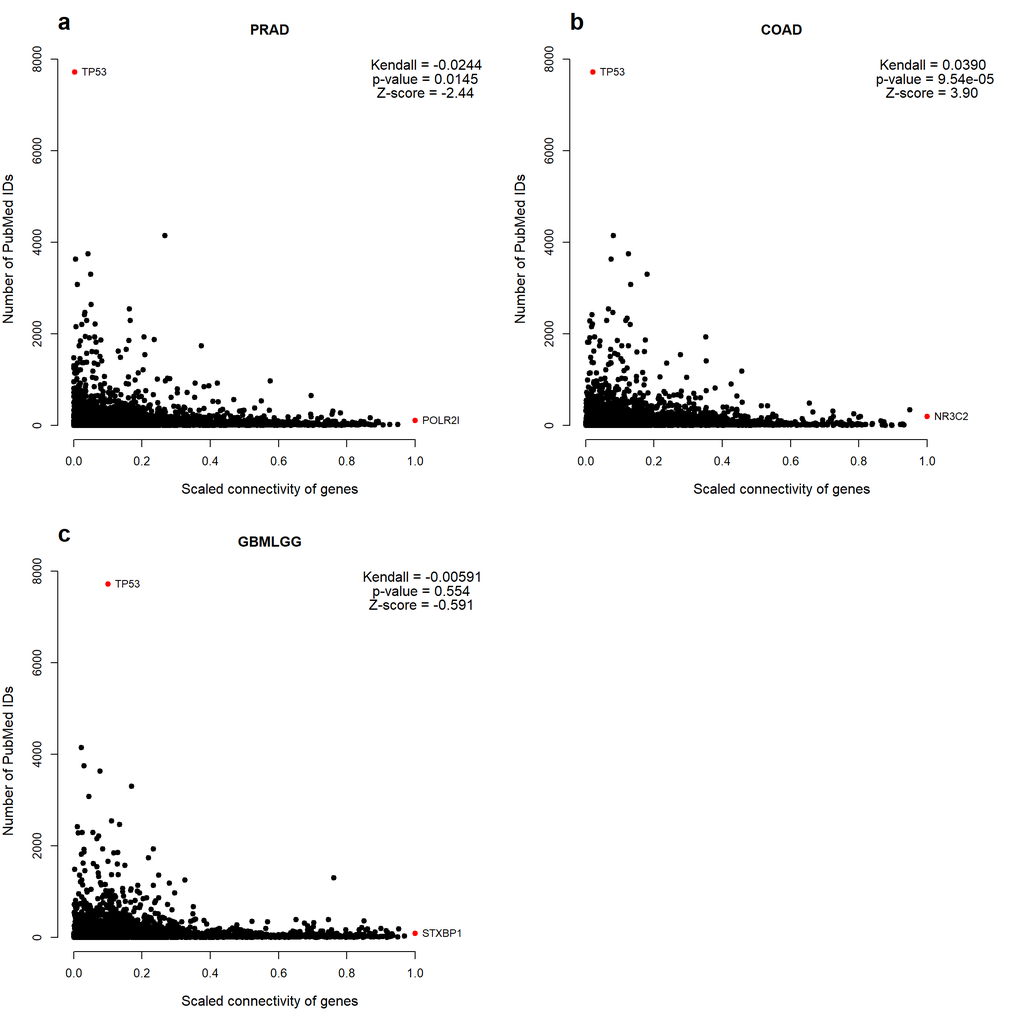

```r
layout(matrix(c(1,2,3,0), 2, 2, byrow = TRUE),
       widths=c(1.5,1.5), heights=c(1,1))

plot(data = connectivity_PubMed_PRAD, PubMed ~ scaledconnectivity, xlim = c(0, 1.15),
     xlab = "Scaled connectivity of genes", ylab = "Number of PubMed IDs", pch=19, main = "PRAD",
     frame.plot = FALSE, cex.lab = 1.2,
     col=ifelse(PubMed > 7000 | scaledconnectivity == max(scaledconnectivity), "red", "black"))
with(data = connectivity_PubMed_PRAD,
     text(PubMed ~ scaledconnectivity, pos = 4, cex = 0.9,
          labels=ifelse(PubMed > 7000 | scaledconnectivity == max(scaledconnectivity),
                        as.character(connectivity_PubMed_PRAD$genename), "")))
title(main ="a", adj=0, line=2, font=2, cex.main = 2)
mtext("Kendall = -0.0244", side = 3, line = -1, adj = 1, cex = 1)
mtext("p-value = 0.0145 ", side = 3, line = -2, adj = 1, cex = 1)
mtext("Z-score = -2.44  ", side = 3, line = -3, adj = 1, cex = 1)

plot(data = connectivity_PubMed_COAD, PubMed ~ scaledconnectivity, xlim = c(0, 1.15),
     xlab = "Scaled connectivity of genes", ylab = "Number of PubMed IDs", pch=19, main = "COAD",
     frame.plot = FALSE, cex.lab = 1.2,
     col=ifelse(PubMed > 7000 | scaledconnectivity == max(scaledconnectivity), "red", "black"))
with(data = connectivity_PubMed_COAD,
     text(PubMed ~ scaledconnectivity, pos = 4, cex = 0.9,
          labels=ifelse(PubMed > 7000 | scaledconnectivity == max(scaledconnectivity),
                        as.character(connectivity_PubMed_COAD$genename), "")))
title(main ="b", adj=0, line=2, font=2, cex.main = 2)
mtext("Kendall = 0.0390  ", side = 3, line = -1, adj = 1, cex = 1)
mtext("p-value = 9.54e-05", side = 3, line = -2, adj = 1, cex = 1)
mtext("Z-score = 3.90    ", side = 3, line = -3, adj = 1, cex = 1)

plot(data = connectivity_PubMed_GBMLGG, PubMed ~ scaledconnectivity, xlim = c(0, 1.15),
     xlab = "Scaled connectivity of genes", ylab = "Number of PubMed IDs", pch=19, main = "GBMLGG",
     frame.plot = FALSE, cex.lab = 1.2,
     col=ifelse(PubMed > 7000 | scaledconnectivity == max(scaledconnectivity), "red", "black"))
with(data = connectivity_PubMed_GBMLGG,
     text(PubMed ~ scaledconnectivity, pos = 4, cex = 0.9,
          labels=ifelse(PubMed > 7000 | scaledconnectivity == max(scaledconnectivity),
                        as.character(connectivity_PubMed_GBMLGG$genename), "")))
title(main ="c", adj=0, line=2, font=2, cex.main = 2)
mtext("Kendall = -0.00591", side = 3, line = -1, adj = 1, cex = 1)
mtext("p-value = 0.554   ", side = 3, line = -2, adj = 1, cex = 1)
mtext("Z-score = -0.591  ", side = 3, line = -3, adj = 1, cex = 1)
```

# 8. Create Figure 3

Kendall correlation between Gleason score and number of PubMed publications for PRAD:

```r
corAndPvalue(Gleason_connectivity_PubMed_PRAD$PubMed, Gleason_connectivity_PubMed_PRAD$GleasonScore, method = "kendall")
```

```
## $cor
##            [,1]
## [1,] 0.04861941
##
## $p
##             [,1]
## [1,] 0.004876406
##
## $Z
##          [,1]
## [1,] 2.815852
##
## $t
##          [,1]
## [1,] 2.816963
##
## $nObs
##      [,1]
## [1,] 3351
```

Kendall correlation between aggressiveness score and number of PubMed publications for COAD:

```r
corAndPvalue(aggressiveness_connectivity_PubMed_COAD$PubMed,aggressiveness_connectivity_PubMed_COAD$aggressiveness,
             method = "kendall")
```

```
## $cor
##             [,1]
## [1,] -0.08249441
##
## $p
##            [,1]
## [1,] 0.02023884
##
## $Z
##           [,1]
## [1,] -2.323947
##
## $t
##          [,1]
## [1,] 2.326595
##
## $nObs
##      [,1]
## [1,]  792
```

Kendall correlation between Cindex score and number of PubMed publications for GBMLGG:

```r
corAndPvalue(Cindex_connectivity_PubMed_GBMLGG$PubMed, Cindex_connectivity_PubMed_GBMLGG$C_index, method = "kendall")
```

```
## $cor
##            [,1]
## [1,] 0.06252773
##
## $p
##              [,1]
## [1,] 0.0005994756
##
## $Z
##          [,1]
## [1,] 3.433257
##
## $t
##          [,1]
## [1,] 3.435501
##
## $nObs
##      [,1]
## [1,] 3009
```

Now we can plot Figure 3:

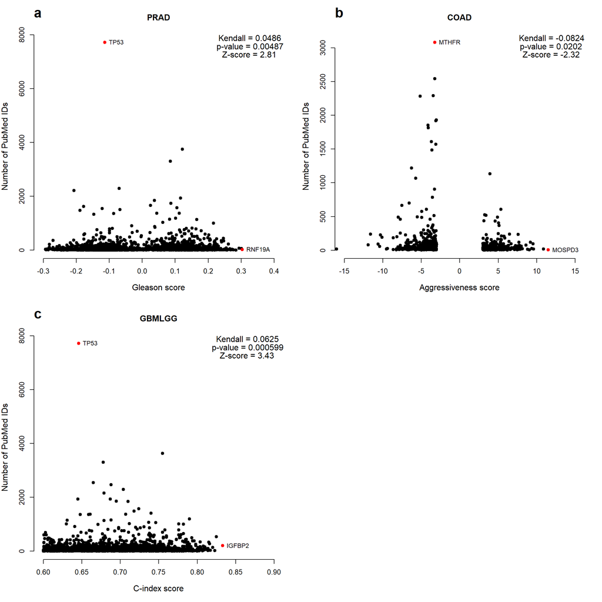

```r
layout(matrix(c(1,2,3,0), 2, 2, byrow = TRUE),
       widths=c(1.2,1.2), heights=c(1,1))

plot(data = Gleason_connectivity_PubMed_PRAD, PubMed ~ GleasonScore,
     xlab = "Gleason score", ylab = "Number of PubMed IDs", pch=19, main = "PRAD", xlim = c(-0.3, 0.4),
     frame.plot = FALSE, cex.lab = 1.2,
     col=ifelse(PubMed == max(PubMed)|  GleasonScore> 0.302 , "red", "black"))
with(data = Gleason_connectivity_PubMed_PRAD,
     text(PubMed ~GleasonScore, pos = 4, cex = 0.9,
          labels=ifelse(PubMed == max(PubMed)|  GleasonScore > 0.302,
                        Gleason_connectivity_PubMed_PRAD$gemename, "")))
title(main ="a", adj=0, line=2, font=2, cex.main = 2)
mtext("Kendall = 0.0486 ", side = 3, line = -1, adj = 1, cex = 1)
mtext("p-value = 0.00487", side = 3, line = -2, adj = 1, cex = 1)
mtext("Z-score = 2.81   ", side = 3, line = -3, adj = 1, cex = 1)


plot(data = aggressiveness_connectivity_PubMed_COAD, PubMed ~ aggressiveness,
     xlab = "Aggressiveness score", ylab = "Number of PubMed IDs", pch=19, main = "COAD", xlim = c(-15, 15),
     frame.plot = FALSE, cex.lab = 1.2,
     col=ifelse(aggressiveness > 11|PubMed == max(PubMed), "red", "black"))
with(data = aggressiveness_connectivity_PubMed_COAD, text(PubMed ~ aggressiveness, pos = 4, cex = 0.9,
                                                          labels=ifelse(aggressiveness > 11|PubMed == max(PubMed),
                                                                        as.character(aggressiveness_connectivity_PubMed_COAD$genename), "")))
title(main ="b", adj=0, line=2, font=2, cex.main = 2)
mtext("Kendall = -0.0824", side = 3, line = -1, adj = 1, cex = 1)
mtext("p-value = 0.0202 ", side = 3, line = -2, adj = 1, cex = 1)
mtext("Z-score = -2.32  ", side = 3, line = -3, adj = 1, cex = 1)


plot(data = Cindex_connectivity_PubMed_GBMLGG, PubMed ~ C_index, xlab = "C-index score",
     frame.plot = FALSE, cex.lab = 1.2, xlim = c(0.6,0.9),
     ylab = "Number of PubMed IDs", pch=19, main = "GBMLGG",
     col=ifelse(C_index > 0.83|PubMed == max(PubMed), "red", "black"))
with(data = Cindex_connectivity_PubMed_GBMLGG, text(PubMed ~ C_index, pos = 4, cex = 0.9,
                                                    labels=ifelse(C_index > 0.83|PubMed == max(PubMed),
                                                                  as.character(Cindex_connectivity_PubMed_GBMLGG$gemename),"")))
title(main ="c", adj=0, line=2, font=2, cex.main = 2)
mtext("Kendall = 0.0625  ", side = 3, line = -1, adj = 1, cex = 1)
mtext("p-value = 0.000599", side = 3, line = -2, adj = 1, cex = 1)
mtext("Z-score = 3.43    ", side = 3, line = -3, adj = 1, cex = 1)
```

# 9. Extract modules for network visualization in Cytoscape

## 9a. Extract GBMLGG “saddlebrown” module

```r
#Select modules
modules = c("saddlebrown")

#Select module probes
Genes = colnames(GBMLGGdata1)
inModule = is.finite(match(moduleColors_GBMLGG, modules))
modGenes =Genes[inModule]

#Select the corresponding topological overlap
modTOM = tom_GBMLGG[inModule, inModule]
dimnames(modTOM) = list(modGenes, modGenes)

#Export the network into edge and node list files Cytoscape can read
cyt = exportNetworkToCytoscape(modTOM,
                               edgeFile = paste("GBMLGG_edges_", paste(modules, collapse="_"), ".txt", sep=""),
                               nodeFile = paste("GBMLGG_nodes_", paste(modules, collapse="_"), ".txt", sep=""),
                               weighted = TRUE,
                               threshold = 0.06,
                               nodeNames = modGenes,
                               nodeAttr = moduleColors_GBMLGG[inModule])
```

## 9b. Extract COAD “cyan” module containing APOL6

```r
#Select modules
modules = c("cyan")

#Select module probes
Genes = colnames(COADdata1)
inModule = is.finite(match(moduleColors_COAD, modules))
modGenes =Genes[inModule]

#Select the corresponding Topological Overlap
modTOM = tom_COAD[inModule, inModule]
dimnames(modTOM) = list(modGenes, modGenes)

#Export the network into edge and node list files Cytoscape can read
cyt = exportNetworkToCytoscape(modTOM,
                               edgeFile = paste("COAD_edges_", paste(modules, collapse="_"), ".txt", sep=""),
                               nodeFile = paste("COAD_nodes_", paste(modules, collapse="_"), ".txt", sep=""),
                               weighted = TRUE,
                               threshold = 0.06,
                               nodeNames = modGenes,
                               nodeAttr = moduleColors_COAD[inModule])
```

## 9c. Extract COAD “blue” module containing C6orf48

```r
#Select modules
modules = c("blue")

#Select module probes
Genes = colnames(COADdata1)
inModule = is.finite(match(moduleColors_COAD, modules))
modGenes =Genes[inModule]

#Select the corresponding Topological Overlap
modTOM = tom_COAD[inModule, inModule]
dimnames(modTOM) = list(modGenes, modGenes)

#Export the network into edge and node list files Cytoscape can read
cyt = exportNetworkToCytoscape(modTOM,
                               edgeFile = paste("COAD_edges_", paste(modules, collapse="_"), ".txt", sep=""),
                               nodeFile = paste("COAD_nodes_", paste(modules, collapse="_"), ".txt", sep=""),
                               weighted = TRUE,
                               threshold = 0.02,
                               nodeNames = modGenes,
                               nodeAttr = moduleColors_COAD[inModule])
```